# Iimage_classifier_project

## Save the checkpoint

Now that your network is trained, save the model so you can load it later for making predictions. You probably want to save other things such as the mapping of classes to indices which you get from one of the image datasets: `image_datasets['train'].class_to_idx`. You can attach this to the model as an attribute which makes inference easier later on.

`model.class_to_idx = image_datasets['train'].class_to_idx`

Remember that you'll want to completely rebuild the model later so you can use it for inference. Make sure to include any information you need in the checkpoint. If you want to load the model and keep training, you'll want to save the number of epochs as well as the optimizer state, `optimizer.state_dict`. You'll likely want to use this trained model in the next part of the project, so best to save it now.

```python
# TODO: Save the checkpoint

def saveCheckpoint(model):

    '''
    Defines a function called saveCheckpoint that takes a model as input. The purpose of this
    function is to save the model's checkpoint, which includes important information about the model's
    architecture, parameters, and other metadata

    '''

    # Mapping the classes to indices
    model.class_to_idx = train_data.class_to_idx

    # Creating a dictionary called checkpoint. This dictionary contains the following key-value pairs:
    # 'name': The name of the model.
    # 'class_to_idx': The mapping of classes to indices.
    # 'classifier': The model's classifier (assuming it has one).
    # 'model_state_dict': The state dictionary of the model, which includes all the learnable
    # parameters of the model.
    checkpoint = {
        'name': model.name,
        'class_to_idx': model.class_to_idx,
        'classifier': model.classifier,
        'model_state_dict': model.state_dict()
    }

    # Generating a unique file name for the checkpoint by appending the current date and time to the
    # string 'model_'. The time.strftime function is used to format the current date and time.
    timestr = time.strftime("%Y%m%d_%H%M%S")
    file_name = 'model_' + timestr + '.pth'

    # The torch.save function is called to save the checkpoint dictionary to a file with the generated
    # file name. The file is saved with the .pth extension, which is commonly used for PyTorch checkpoints.
    torch.save(checkpoint, file_name)

    # The function returns the file name of the saved checkpoint.
    return file_name
```

```python
# To show the filename
filename
```

```
'model.pt'
```

## Loading the checkpoint

At this point it's good to write a function that can load a checkpoint and rebuild the model. That way you can come back to this project and keep working on it without having to retrain the network.

```python
# TODO: Write a function that loads a checkpoint and rebuilds the model

def rebuildModel(filepath):
    '''
    The purpose of this function is to rebuild a pretrained model using the saved checkpoint file. It
    takes a file path as input.

    '''

    try:
        # To load the checkpoint file using the torch.load function. The map_location argument is used to
        # specify the device where the model should be loaded. In this case, lambda storage, loc: storage
        # is used to load the model on the CPU.
        checkpoint = torch.load(filepath, map_location=lambda storage, loc: storage)

        # To recreate the pretrained base model using the getattr function. The getattr function is used
        # to dynamically access a module or attribute based on its name. In this case, it accesses the
        # model specified by checkpoint['name'] from the models module and initializes it with pretrained
        # weights.
        model = getattr(models, checkpoint['name'])(pretrained=True)

        # Replacing the classifier part of the model with the one saved in the checkpoint file. The
        # checkpoint['classifier'] contains the classifier information.
        model.classifier = checkpoint['classifier']

        # loading the saved state dictionary of the model using the load_state_dict function. The state
        # dictionary contains the parameter values of the model.
        model.load_state_dict(checkpoint['model_state_dict'])

        # To assign the class_to_idx dictionary from the checkpoint file to the class_to_idx attribute of
        # the model. This dictionary maps class labels to their corresponding indices.
        model.class_to_idx = checkpoint['class_to_idx']

        # Move the model to GPU if available
        if torch.cuda.is_available():
            model.to('cuda')

        # To return the rebuilt model.
        return model

    except Exception as e:
        print("Error occurred while rebuilding the model:", str(e))
        return None
```

```python
# To catch a glimpse of rebuilt model
model
```

```
VGG(
  (features): Sequential(
    (0): Conv2d(3, 64, kernel_size=(3, 3), stride=(1, 1), padding=(1, 1))
    (1): ReLU(inplace=True)
    (2): Conv2d(64, 64, kernel_size=(3, 3), stride=(1, 1), padding=(1, 1))
    (3): ReLU(inplace=True)
    (4): MaxPool2d(kernel_size=2, stride=2, padding=0, dilation=1, ceil_mode=False)
    (5): Conv2d(64, 128, kernel_size=(3, 3), stride=(1, 1), padding=(1, 1))
    (6): ReLU(inplace=True)
    (7): Conv2d(128, 128, kernel_size=(3, 3), stride=(1, 1), padding=(1, 1))
    (8): ReLU(inplace=True)
    (9): MaxPool2d(kernel_size=2, stride=2, padding=0, dilation=1, ceil_mode=False)
    (10): Conv2d(128, 256, kernel_size=(3, 3), stride=(1, 1), padding=(1, 1))
    (11): ReLU(inplace=True)
    (12): Conv2d(256, 256, kernel_size=(3, 3), stride=(1, 1), padding=(1, 1))
    (13): ReLU(inplace=True)
    (14): Conv2d(256, 256, kernel_size=(3, 3), stride=(1, 1), padding=(1, 1))
    (15): ReLU(inplace=True)
    (16): MaxPool2d(kernel_size=2, stride=2, padding=0, dilation=1, ceil_mode=False)
    (17): Conv2d(256, 512, kernel_size=(3, 3), stride=(1, 1), padding=(1, 1))
    (18): ReLU(inplace=True)
    (19): Conv2d(512, 512, kernel_size=(3, 3), stride=(1, 1), padding=(1, 1))
    (20): ReLU(inplace=True)
    (21): Conv2d(512, 512, kernel_size=(3, 3), stride=(1, 1), padding=(1, 1))
    (22): ReLU(inplace=True)
    (23): MaxPool2d(kernel_size=2, stride=2, padding=0, dilation=1, ceil_mode=False)
    (24): Conv2d(512, 512, kernel_size=(3, 3), stride=(1, 1), padding=(1, 1))
    (25): ReLU(inplace=True)
    (26): Conv2d(512, 512, kernel_size=(3, 3), stride=(1, 1), padding=(1, 1))
    (27): ReLU(inplace=True)
    (28): Conv2d(512, 512, kernel_size=(3, 3), stride=(1, 1), padding=(1, 1))
    (29): ReLU(inplace=True)
    (30): MaxPool2d(kernel_size=2, stride=2, padding=0, dilation=1, ceil_mode=False)
  )
  (avgpool): AdaptiveAvgPool2d(output_size=(7, 7))
  (classifier): Classifier(
    (hidden_layers): ModuleList(
      (0): Linear(in_features=25088, out_features=4096, bias=True)
      (1): Linear(in_features=4096, out_features=1024, bias=True)
    )
    (output): Linear(in_features=1024, out_features=102, bias=True)
    (dropout): Dropout(p=0.2, inplace=False)
  )
)
```

# Inference for classification

Now you'll write a function to use a trained network for inference. That is, you'll pass an image into the network and predict the class of the flower in the image. Write a function called `predict` that takes an image and a model, then returns the top $K$ most likely classes along with the probabilities. It should look like

```
probs, classes = predict(image_path, model)
print(probs)
print(classes)
> [ 0.01558163  0.01541934  0.01452626  0.01443549  0.01407339]
> ['70', '3', '45', '62', '55']
```

First you'll need to handle processing the input image such that it can be used in your network.

## Image Preprocessing

You'll want to use `PIL` to load the image ([documentation](https://pillow.readthedocs.io/en/latest/reference/Image.html)). It's best to write a function that preprocesses the image so it can be used as input for the model. This function should process the images in the same manner used for training.

First, resize the images where the shortest side is 256 pixels, keeping the aspect ratio. This can be done with the [`thumbnail`](http://pillow.readthedocs.io/en/3.1.x/reference/Image.html#PIL.Image.Image.thumbnail) or [`resize`](http://pillow.readthedocs.io/en/3.1.x/reference/Image.html#PIL.Image.Image.thumbnail) methods. Then you'll need to crop out the center 224x224 portion of the image.

Color channels of images are typically encoded as integers 0-255, but the model expected floats 0-1. You'll need to convert the values. It's easiest with a Numpy array, which you can get from a PIL image like so `np_image = np.array(pil_image)`.

As before, the network expects the images to be normalized in a specific way. For the means, it's `[0.485, 0.456, 0.406]` and for the standard deviations `[0.229, 0.224, 0.225]`. You'll want to subtract the means from each color channel, then divide by the standard deviation.

And finally, PyTorch expects the color channel to be the first dimension but it's the third dimension in the PIL image and Numpy array. You can reorder dimensions using [`ndarray.transpose`](https://docs.scipy.org/doc/numpy-1.13.0/reference/generated/numpy.ndarray.transpose.html). The color channel needs to be first and retain the order of the other two dimensions.

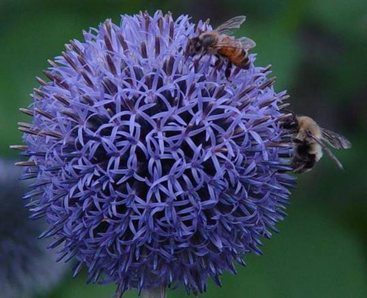

```python
# Testing default image display before transformations are applied

image_path = 'flowers/test/10/image_07090.jpg'
img = Image.open(image_path)
img
```

```python
def process_image(image):
    ''' Scales, crops, and normalizes a PIL image for a PyTorch model,
        returns a Numpy array
    '''

    # Check if the width of the image is greater than its height
    if image.width > image.height:
        image.thumbnail((10000000, 256))   # Constraining the height to be 256
    else:
        image.thumbnail((256, 10000000))   # Constraining the width to be 256

    # Perform a center crop on the image
    crop_size = 224
    left_margin = (image.width - crop_size) / 2
    bottom_margin = (image.height - crop_size) / 2
    right_margin = left_margin + crop_size
    top_margin = bottom_margin + crop_size
    image = image.crop((left_margin, bottom_margin, right_margin, top_margin))

    # Convert the image to a NumPy array
    np_image = np.array(image)

    # Normalize the image
    np_image = np_image / 255

    # Standardize the image
    means = np.array([0.485, 0.456, 0.406])
    stds = np.array([0.229, 0.224, 0.225])
    np_image = (np_image - means) / stds

    # Transpose the color channels
    np_image = np_image.transpose(2, 0, 1)

    # Return the preprocessed image
    return np_image
```

To check your work, the function below converts a PyTorch tensor and displays it in the notebook. If your `process_image` function works, running the output through this function should return the original image (except for the cropped out portions).

```python
def imshow(image, ax=None, title=None):
    """Imshow for Tensor."""
    if ax is None:
        fig, ax = plt.subplots()

    # PyTorch tensors assume the color channel is the first dimension
    # but matplotlib assumes it is the third dimension
    image = image.transpose((1, 2, 0))

    # Undo preprocessing
    mean = np.array([0.485, 0.456, 0.406])
    std = np.array([0.229, 0.224, 0.225])
    image = std * image + mean

    # Image needs to be clipped between 0 and 1 or it looks like noise when displayed
    image = np.clip(image, 0, 1)

    ax.imshow(image)

    return ax
```

```
WARNING:matplotlib.image:Clipping input data to the valid range for imshow with RGB data ([0..1] for floats or [0..255] for integers).
```

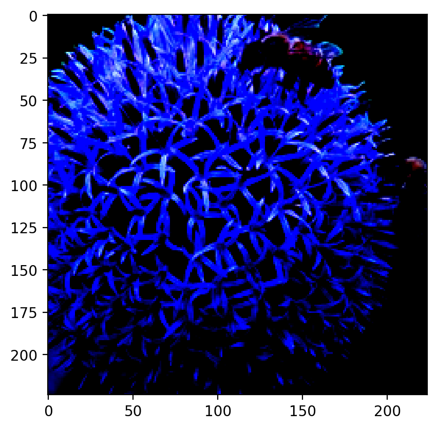

```python
img_ready = Image.open(image_path)
img_ready = process_image(img_ready)

plt.imshow(img_ready.transpose((1, 2, 0)))
plt.show()
```

## Class Prediction

Once you can get images in the correct format, it's time to write a function for making predictions with your model. A common practice is to predict the top 5 or so (usually called top-$K$) most probable classes. You'll want to calculate the class probabilities then find the $K$ largest values.

To get the top $K$ largest values in a tensor use [`x.topk(k)`](http://pytorch.org/docs/master/torch.html#torch.topk). This method returns both the highest `k` probabilities and the indices of those probabilities corresponding to the classes. You need to convert from these indices to the actual class labels using `class_to_idx` which hopefully you added to the model or from an `ImageFolder` you used to load the data (see here). Make sure to invert the dictionary so you get a mapping from index to class as well.

Again, this method should take a path to an image and a model checkpoint, then return the probabilities and classes.

```
probs, classes = predict(image_path, model)
print(probs)
print(classes)
> [ 0.01558163  0.01541934  0.01452626  0.01443549  0.01407339]
> ['70', '3', '45', '62', '55']
```

```python
model = torch.load('model.pt')
```

```python
def predict(image_path, model, topk=5):
    ''' Predicts the class (or classes) of an image using a trained deep learning model.
    '''

    # TODO: Implement the code to predict the class from an image file

    # To move the model into evaluation mode and to CPU
    model.eval()

    # To open the image located at image_path using the PIL library's Image.open() function.
    image = Image.open(image_path)

    # To process the image using a function called process_image(). This function applies
    # transformations to the image, such as resizing, cropping, and normalizing, to prepare it for
    # input into the model.
    image = process_image(image)

    # To convert the processed image, which is a NumPy array, into a PyTorch tensor of type
    # torch.FloatTensor
    image = torch.tensor(image, dtype=torch.float)

    # To add a batch dimension to the image tensor. The model expects input in the shape of
    # (batch_size, channels, height, width), so the unsqueeze() function adds a dimension of size 1 at
    # the beginning.
    image = image.unsqueeze(0)

    # To pass the image tensor through the model's forward method to obtain the predicted
    # probabilities for each class. The torch.exp() function is used to reverse the log conversion
    # that might have been applied to the output probabilities.
    probs = torch.exp(model.forward(image))

    # To select the top topk probabilities and their corresponding labels from the predicted
    # probabilities. The topk() function returns the topk largest elements and their indices.
    top_probs, top_labs = probs.topk(topk)

    # To convert the top probabilities from PyTorch tensors to NumPy arrays and then to a Python list.
    top_probs = top_probs.squeeze().tolist()

    # To create a dictionary that maps the indices of the model's classes to their respective labels.
    idx_to_class = {model.class_to_idx[k]: k for k in model.class_to_idx}

    # initializes an empty list to store the labels.
    labs = []

    # To convert the top labels to their respective class names, using a list comprehension
    labs = [idx_to_class[label.item()] for label in top_labs.squeeze()]

    # returns the top probabilities and labels as a tuple
    return top_probs, labs
```

```python
model.class_to_idx = image_datasets['train'].class_to_idx
```

```python
# Using the predict function to predict the class of an image using our pre-trained model.

# calls the predict function with three arguments: image_path, model_from_file, and topk=5.
# The image_path is the path to the image file, model_from_file is the pre-trained model loaded from
# a file, and topk=5 specifies that the function should return the top 5 predicted probabilities and
# their corresponding classes.
probs, classes = predict(image_path, model, topk=5)

# to see the path of the image being classified, the predicted probabilities for each class, and the
# corresponding class labels.
print(image_path)
print(probs)
print(classes)
```

```
flowers/test/10/image_07090.jpg
[0.01192003209143877, 0.011503048241138458, 0.011291624046862125, 0.011263370513916016, 0.011176501400768757]
['59', '63', '90', '77', '33']
```

```python
def convertCategoryToName(categories, mapper='cat_to_name.json'):

    ''' The purpose of this function is to map the predicted categories (represented as numbers) to
    their corresponding flower names. It does this by loading a JSON file (cat_to_name.json) that
    contains a mapping between category numbers and flower names. The function then retrieves the
    flower names for the predicted categories and returns them as a list.

    '''

    # opens the JSON file specified by the mapper parameter in read mode. The mapper parameter is set
    # to 'cat_to_name.json' by default. The with statement ensures that the file is properly closed
    # after it is used.
    with open(mapper, 'r') as f:

        # loads the contents of the JSON file into the cat_to_name variable. The json.load() function
        # is used to parse the JSON data from the file.
        cat_to_name = json.load(f)

        # initializes an empty list called names. This list will store the flower names corresponding
        # to the predicted categories.
        names = []

        # starts a loop that iterates over each element in the categories list.
        for category in categories:

            # retrieves the flower name corresponding to the current category from the cat_to_name
            # dictionary and appends it to the names list. The str(category) is used to ensure that
            # the category is converted to a string before accessing the dictionary.
            names.append(cat_to_name[str(category)])

    # returns the names list, which contains the flower names corresponding to the predicted categories.
    return names
```

```python
# To make the predictions more interpretable and easier to understand, we translate the class
# identifiers into names

# calls the convertCategoryToName function with the classes variable as an argument. The classes
# variable contains the predicted class identifiers. The function maps these class identifiers to
# their corresponding names and returns a list of human-friendly names, which is assigned to the
# names variable.
names = convertCategoryToName(classes)

print(probs)
print(classes)
print(names)
```

```
[0.01192003209143877, 0.011503048241138458, 0.011291624046862125, 0.011263370513916016, 0.011176501400768757]
['59', '63', '90', '77', '33']
['orange dahlia', 'black-eyed susan', 'canna lily', 'passion flower', 'love in the mist']
```

## Sanity Checking

Now that you can use a trained model for predictions, check to make sure it makes sense. Even if the testing accuracy is high, it's always good to check that there aren't obvious bugs. Use `matplotlib` to plot the probabilities for the top 5 classes as a bar graph, along with the input image. It should look like this:

[figure not shown]

You can convert from the class integer encoding to actual flower names with the `cat_to_name.json` file (should have been loaded earlier in the notebook). To show a PyTorch tensor as an image, use the `imshow` function defined above.

```python
def select_random_image(path):

    '''
    The purpose of this function is to randomly select an image file path from a specified parent path.
    It does this by randomly selecting a folder from the parent path, and then randomly selecting a
    file from that folder. The function then returns the full path to the randomly selected image file.
    It takes a single parameter path.

    '''

    # selects a random folder from the list of folders in the specified path directory.
    # The os.listdir() function is used to get a list of all the files and folders in the specified
    # directory, and random.choice() is used to select a random folder from that list.
    random_folder = random.choice(os.listdir(path))

    # selects a random file from the list of files in the randomly chosen folder.
    # The os.path.join() function is used to join the path and random_folder together to create the
    # full path to the folder. Then, os.listdir() is used to get a list of all the files in that
    # folder, and random.choice() is used to select a random file from that list.
    random_file = random.choice(os.listdir(os.path.join(path, random_folder)))

    # creates the full image path by joining the path, random_folder, and random_file together using
    # the os.path.join() function.
    image_path = os.path.join(path, random_folder, random_file)

    # returns the image_path, which is the randomly selected image file path.
    return image_path
```

```python
def display_preds(path, model, topk=5, flower_names=None):

    '''
    The purpose of this function is to select a random image, predict its class using the provided
    model, and visualize the prediction result. It displays the image along with the predicted class
    probabilities in the form of a bar plot. It takes four parameters: path, model, topk, and
    flower_names.

    '''

    # calls the select_random_image function to get a random image file path from the specified path
    # directory. The image_path variable stores the randomly selected image file path.
    image_path = select_random_image(path)
    #print(image_path)

    # extracts the folder number from the image_path. The image_path is split using the forward slash
    # ('/') as the delimiter, and the third element of the resulting list is assigned to the
    # folder_number variable. This folder number corresponds to the class identifier of the image.
    folder_number = image_path.split('/')[2]
    #print(folder_number)

    # retrieves the flower name based on the folder_number from the flower_names dictionary. The
    # flower_names dictionary maps the class identifiers to their corresponding flower names. The
    # retrieved flower name is assigned to the title variable.
    title = flower_names[folder_number]
    #print(title)

    # calls the predict function with the image_path, model, and topk parameters to predict the class
    # probabilities and class identifiers for the image. The predicted probabilities are assigned to
    # the probs variable, and the predicted class identifiers are assigned to the classes variable.
    probs, classes = predict(image_path, model, topk)
    #print(probs)
    #print(classes)

    # calls the convertCategoryToName function with the classes variable as an argument to convert the
    # class identifiers into their corresponding names. The resulting names are assigned to the names
    # variable.
    names = convertCategoryToName(classes)
    print('n:', names)
    print('c:', classes)

    # opens the image using the Image.open() function from the PIL library. The image variable stores
    # the opened image.
    image = Image.open(image_path)

    # preprocesses the image using the process_image function. The process_image function applies
    # transformations to the image to make it compatible with the PyTorch model.
    image = process_image(image)

    # sets up a plot with a figure size of 6 inches by 10 inches.
    plt.figure(figsize = (6, 10))

    # creates a subplot with 2 rows, 1 column, and selects the first subplot.
    ax = plt.subplot(2, 1, 1)

    # displays the image using the imshow function, passing in the image, ax, and title as
    # arguments. The imshow function is responsible for visualizing the image with the provided title.
    imshow(image, ax, title=title);

    # creates a subplot with 2 rows, 1 column, and selects the second subplot.
    plt.subplot(2, 1, 2)

    # creates a bar plot using the Seaborn library. It visualizes the predicted probabilities (probs)
    # on the x-axis and the corresponding class names (names) on the y-axis. The color of the bars is
    # set using the first color from the default Seaborn color palette.
    sns.barplot(x=probs, y=names, color=sns.color_palette()[0]);

    # displays the plot.
    plt.show()

    # indicates the end of the function and returns nothing.
    return
```

```
n: ['bishop of llandaff', 'hibiscus', 'geranium', 'thorn apple', 'columbine']
c: ['56', '83', '58', '75', '84']
```

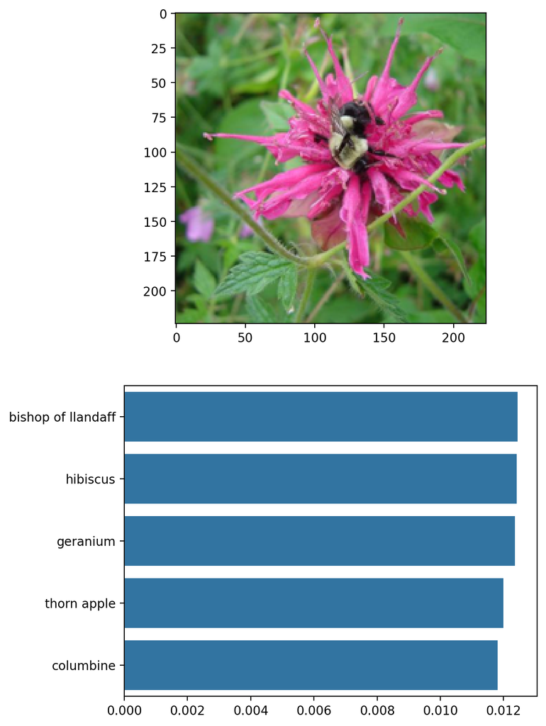

```
n: ['hibiscus', 'canna lily', 'poinsettia', 'columbine', 'passion flower']
c: ['83', '90', '44', '84', '77']
```

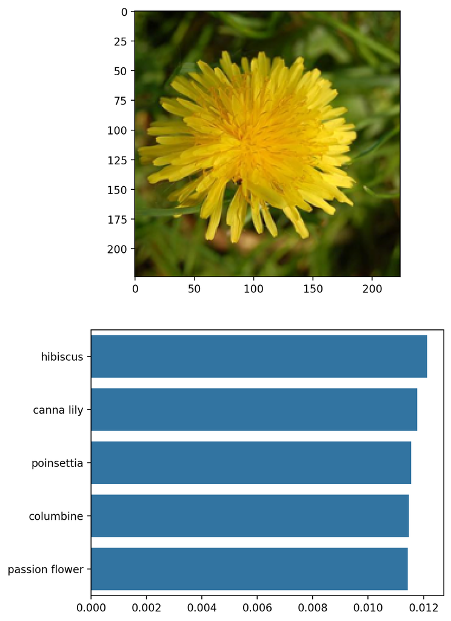

```
n: ['orange dahlia', 'peruvian lily', 'canna lily', 'frangipani', 'mexican petunia']
c: ['59', '18', '90', '81', '98']
```

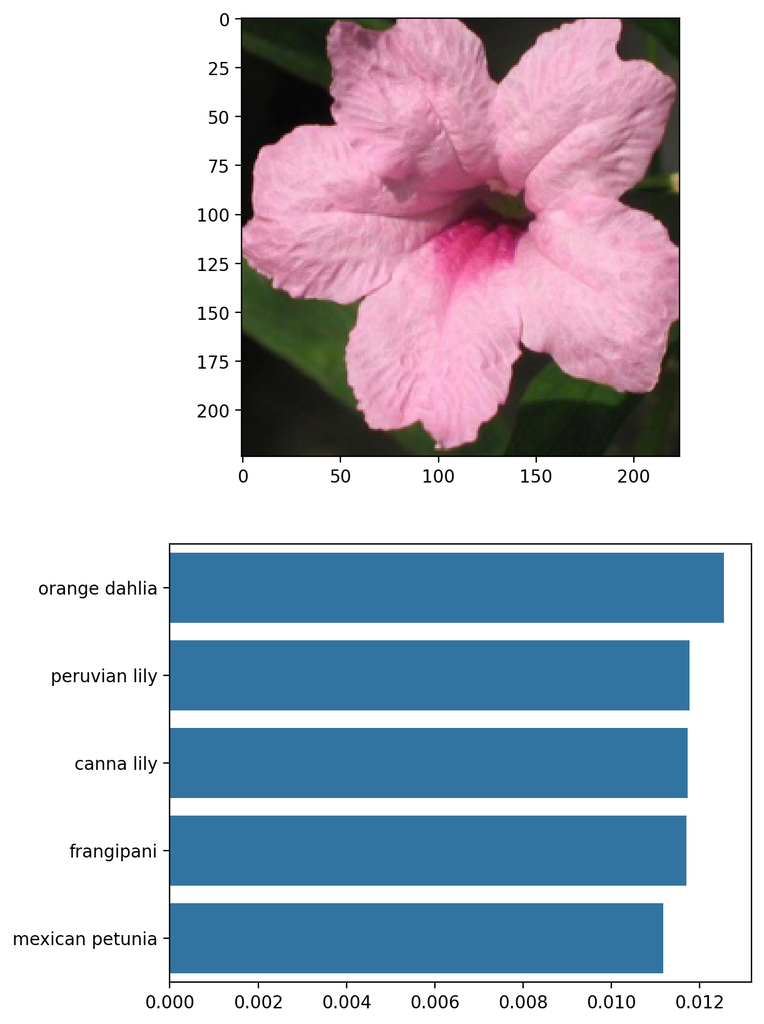

```
n: ['passion flower', 'columbine', 'bishop of llandaff', 'ruby-lipped cattleya', 'hibiscus']
c: ['77', '84', '56', '36', '83']
```

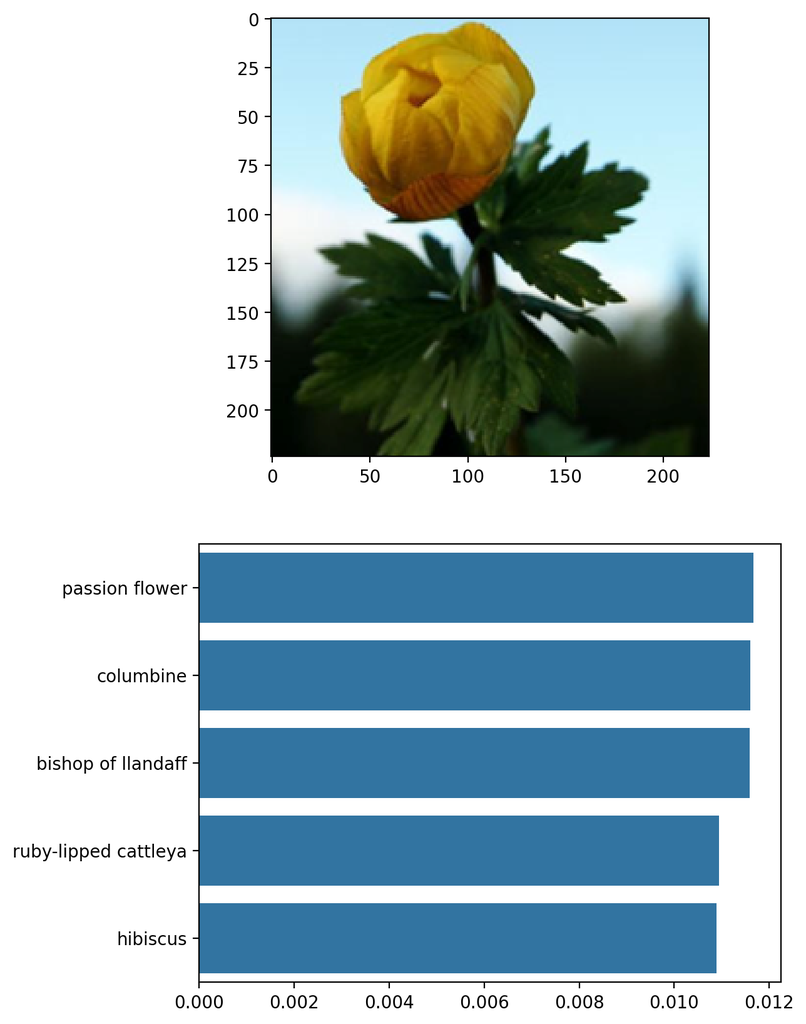

```
n: ['azalea', 'hibiscus', 'frangipani', 'peruvian lily', 'spring crocus']
c: ['72', '83', '81', '18', '67']
```

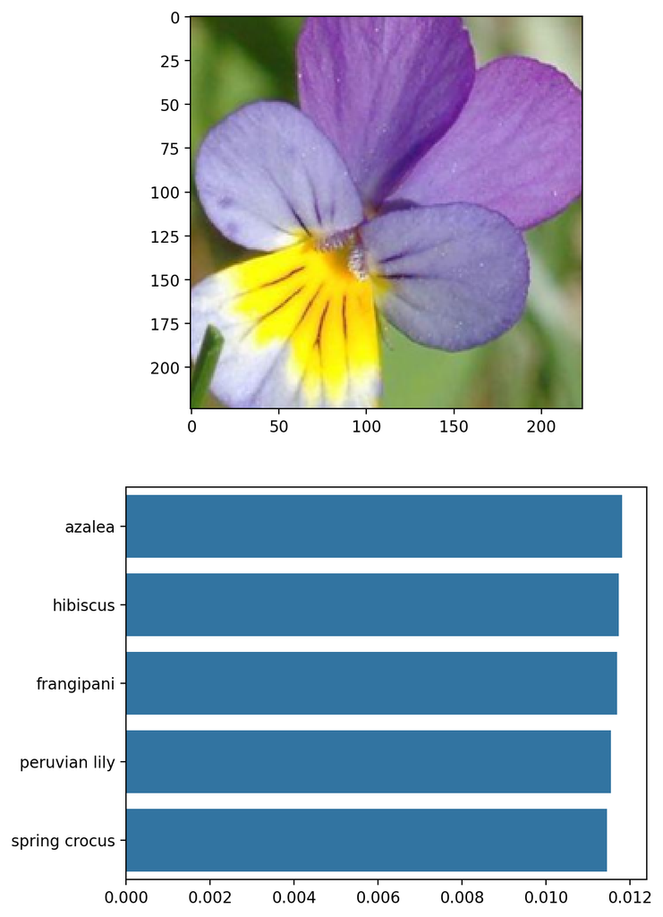

```python
# TODO: Display an image along with the top 5 classes


# assigns the value 5 to the variable number_of_predictions. This variable determines the number of
# images for which predictions will be performed.
number_of_predictions = 5

# starts a loop that will iterate number_of_predictions times (in this case, 5 times). The loop
# variable i will take on values from 0 to number_of_predictions - 1.
for i in range(number_of_predictions):

    # calls the display_preds function with the arguments 'flowers/test' (the path to the test images
    # directory), model_from_file (the pre-trained model), and flower_names=cat_to_name (the dictionary
    # mapping class identifiers to flower names). This function will select a random image from the
    # test directory, predict its class using the model, and visualize the prediction result.
    # By running this loop, the display_preds function will be called number_of_predictions times,
    # each time selecting a different random image from the test directory and displaying its
    # prediction result.
    display_preds('flowers/test', model, flower_names=cat_to_name)
```